# Exploring the Bay Wheels (Lyft) Bike Dataset for August 2021

## Preliminary Wrangling

This document explores a dataset that contains individual rides in August 2021 from a bike-sharing system run by Lyft called Bay Wheels.

### Some Background on Bay Wheels (from www.lyft.com/bikes/bay-wheels)

Bay Wheels bikes are found at more than 400 stations in San Francisco, the East Bay (Oakland, Berkeley and Emeryville) and San Jose. A station is the row of docked bikes; a dock is what holds each individual bicycle.

Bay Wheels offers two kinds of bikes: hybrid electric bikes, which have a battery, and "classic" bikes, which are rider-powered.

There are two kinds of riders: annual or monthly members, and casual riders who either pay by the single ride or who purchase an access pass (which allows unlimited 30-minute rides over a 24 hour period).

In August 2021, the fees were as follows:

- For a casual rider, a single ride starts at \$3 for the first 30 minutes. If the single ride is on an ebike, there is an extra fee of 0.20 per minute.
- An Access Pass is \$10 for a classic bike; an additional 0.30 per minute is charged for ebikes. According Lyft, the Access Pass is popular with tourists.
- Annual memberships are \$159/year and include unlimited 45-minute classic bike rides.
- Monthly memberships are \$25/month and include unlimited 45-minute classic bike rides for 30 days from purchase.
- Members who ride an ebike pay 0.15 per minute during the included ride time.
- Non-member or casual riders pay \$3 for every 15 minutes after the 30-minute ride time has expired.
- Members who ride a classic bike pay \$2 for every 15 minutes after 45 minutes have expired.

The maximum bike rental period is 24 hours; Lyft warns that for bikes kept for more than 24 hours, "you may be charged a lost or stolen bike fee of \$1,200 (plus tax)."

Bay Wheels bikes may be ridden outside the service area, but a rider can end a trip only as follows:

- Classic bikes can only be returned to any station with an open dock.
- Electric bikes can be returned to any Bay Wheels station or locked to any public bike rack within the service area. Parking an ebike at a bike rack, instead of docking at a Bay Wheels station, will cost an additional \$2 for members and casual riders.

```python
# import  packages and set plots to be embedded inline
import numpy as np
import pandas as pd
import matplotlib.pyplot as plt
import seaborn as sns

%matplotlib inline

# suppress warnings from final output
import warnings
warnings.simplefilter("ignore")
```

```python
#load the dataset
df = pd.read_csv("202108-baywheels-tripdata.csv")
```

```python
#make a copy to work on
df_clean = df.copy()
```

```python
#examine the dataframe
df_clean.info()
```

```
<class 'pandas.core.frame.DataFrame'>
RangeIndex: 207023 entries, 0 to 207022
Data columns (total 13 columns):
 #   Column              Non-Null Count   Dtype
---  ------              --------------   -----
 0   ride_id             207023 non-null  object
 1   rideable_type       207023 non-null  object
 2   started_at          207023 non-null  object
 3   ended_at            207023 non-null  object
 4   start_station_name  166811 non-null  object
 5   start_station_id    166811 non-null  object
 6   end_station_name    162712 non-null  object
 7   end_station_id      162712 non-null  object
 8   start_lat           207023 non-null  float64
 9   start_lng           207023 non-null  float64
 10  end_lat             206747 non-null  float64
 11  end_lng             206747 non-null  float64
 12  member_casual       207023 non-null  object
dtypes: float64(4), object(9)
memory usage: 20.5+ MB
```

#### There are 207,023 rows in this dataframe. There are more than 40,000 null values for start_station_name, start_station_id, end_station_name and end_station_id. Only the start and end latitude and longitude values are numerical (float); the rest are objects (strings). Also, it looks like roughly 300 values of end latitude and end longitude are null.

#### Because this is a dataset that is not one of the ones offered on the Google doc, we'll need to do a little preliminary data wrangling before beginning the analysis.

```python
#look at first five rows
df_clean.head()
```

|  | ride_id | rideable_type | started_at | ended_at | start_station_name | start_station_id | end_station_name | end_station_id | start_lat | start_lng | end_lat | end_lng | member_casual |
| --- | --- | --- | --- | --- | --- | --- | --- | --- | --- | --- | --- | --- | --- |
| 0 | A67CB6CC130B48AB | electric_bike | 2021-08-07 13:30:11 | 2021-08-07 14:08:57 | S Van Ness Ave at Market St | SF-J23-2 | The Embarcadero at Bryant St | SF-G30-2 | 37.774554 | -122.419896 | 37.787410 | -122.388207 | member |
| 1 | EA6D1C08FB8D1751 | classic_bike | 2021-08-16 18:34:12 | 2021-08-16 18:34:14 | 7th Ave at Cabrillo St | SF-J12 | 7th Ave at Cabrillo St | SF-J12 | 37.775120 | -122.464998 | 37.775120 | -122.464998 | member |
| 2 | 91E70C07BFA0BAED | electric_bike | 2021-08-31 18:28:04 | 2021-08-31 19:12:40 | 7th Ave at Cabrillo St | SF-J12 | 7th Ave at Cabrillo St | SF-J12 | 37.775129 | -122.464995 | 37.775115 | -122.465001 | member |
| 3 | 1A5E792757C33356 | electric_bike | 2021-08-10 17:52:44 | 2021-08-10 18:02:46 | 23rd St at Tennessee St | SF-Q30 | McKinnon Ave at 3rd St | SF-W29 | 37.755349 | -122.388703 | 37.736519 | -122.389884 | member |
| 4 | B2EA7B7711640610 | electric_bike | 2021-08-11 18:01:21 | 2021-08-11 18:09:37 | 23rd St at Tennessee St | SF-Q30 | McKinnon Ave at 3rd St | SF-W29 | 37.755397 | -122.388636 | 37.736311 | -122.389896 | member |

#### The only numerical values are latitude and longitude. I'll use describe() on the dataset after I have calculated the duration of each ride in seconds, the distance between starting latitude/longitude and ending latitude/longitude and the estimated ride cost.

#### I will rename rideable_type to bike_type and member_casual to rider_type for ease of understanding and tidiness.

```python
df_clean.rename(columns={"rideable_type": "bike_type", "member_casual": "rider_type"}, inplace=True)
```

```python
df_clean.info() #confirming
```

```
<class 'pandas.core.frame.DataFrame'>
RangeIndex: 207023 entries, 0 to 207022
Data columns (total 13 columns):
 #   Column              Non-Null Count   Dtype
---  ------              --------------   -----
 0   ride_id             207023 non-null  object
 1   bike_type           207023 non-null  object
 2   started_at          207023 non-null  object
 3   ended_at            207023 non-null  object
 4   start_station_name  166811 non-null  object
 5   start_station_id    166811 non-null  object
 6   end_station_name    162712 non-null  object
 7   end_station_id      162712 non-null  object
 8   start_lat           207023 non-null  float64
 9   start_lng           207023 non-null  float64
 10  end_lat             206747 non-null  float64
 11  end_lng             206747 non-null  float64
 12  rider_type          207023 non-null  object
dtypes: float64(4), object(9)
memory usage: 20.5+ MB
```

```python
#check that all ride_id values are unique
df_clean["ride_id"].nunique() #yes
```

```
207023
```

```python
#check number of unique start stations by name
df_clean["start_station_name"].nunique()
```

```
465
```

#### What types of Bay Wheels bikes were ridden in August 2021, and how many rides per type?

```python
#examine bike_type
bike_count = df_clean["bike_type"].value_counts()
```

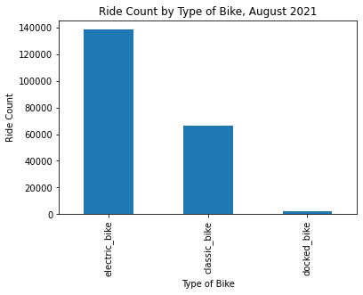

```python
bike_count.plot(kind='bar')
plt.title('Ride Count by Type of Bike, August 2021')
plt.xlabel('Type of Bike')
plt.ylabel("Ride Count");
```

#### More electric bikes were ridden in August 2021 than classic bikes by a 2 to 1 margin. Very few docked bikes were ridden in comparison.

Docked_bikes are not mentioned on the Lyft website. Given that all classic bikes are required to be parked in a docking station, I suspect that a "docked_bike" is simply a classic bike on an Access Pass. We'll have to investigate further in a bit.

#### Let's do a little clean up by converting values in rideable_type and member_casual from string to categorical data type.

```python
df_clean["bike_type"] = df_clean["bike_type"].astype('category')
```

```python
df_clean["rider_type"] = df_clean["rider_type"].astype('category')
```

#### What type of riders used Bay Wheels bikes in August 2021, and how many rides per rider type?

```python
#examine rider_type
rider_count = df_clean["rider_type"].value_counts()
```

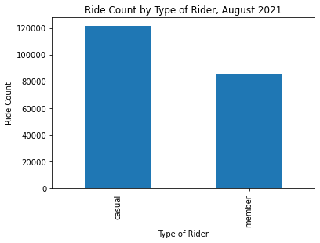

```python
rider_count.plot(kind='bar')
plt.title('Ride Count by Type of Rider, August 2021')
plt.xlabel('Type of Rider')
plt.ylabel("Ride Count");
```

#### More casual (non-member) riders used Bay Wheels in August 2021 by roughly 30,000 more rides.

#### Let's look at the top 10 stations for starts that were not null.

#### What were the top 10 start stations for rides in August 2021?

```python
top_start_stations = df_clean["start_station_name"].value_counts().head(10).sort_values()
```

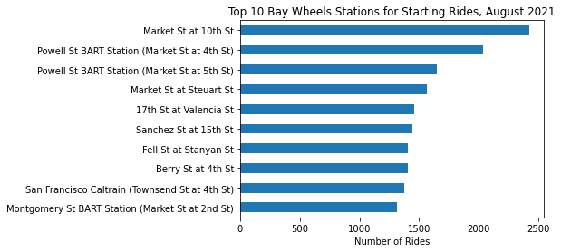

```python
top_start_stations.plot(kind='barh')
plt.title('Top 10 Bay Wheels Stations for Starting Rides, August 2021')
plt.xlabel('Number of Rides');
```

#### The top 10 start stations for rides in August 2021 included four transit stations (BART, Caltrain) as well as the Twitter HQ (Market St at 10th St).

#### What were the top 10 end stations for rides in August 2021?

```python
#top 10 end stations for rides in August 2021
top_end_stations = df_clean["end_station_name"].value_counts().head(10).sort_values()
```

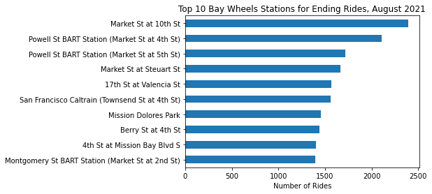

```python
top_end_stations.plot(kind='barh')
plt.title('Top 10 Bay Wheels Stations for Ending Rides, August 2021')
plt.xlabel('Number of Rides');
```

#### The top 10 end stations for rides were in San Francisco, four of which were transit (BART, Caltrain) stations as well as the Twitter HQ (Market St at 10th St). There is some overlap with the top 10 start stations for rides.

#### Let's look at the top 10 start and end stations by bike type.

#### What were the top 10 start stations for docked bikes?

```python
top_docked_stations = df_clean[df_clean["bike_type"]=="docked_bike"]["start_station_name"].\
value_counts().head(10).sort_values()
```

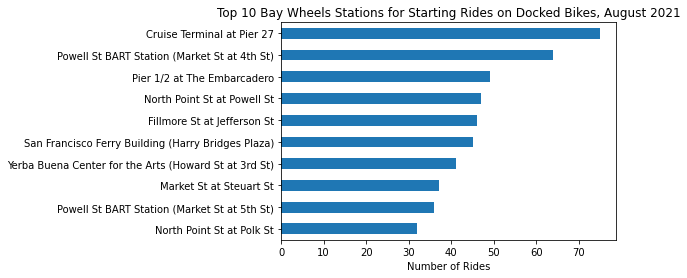

```python
#top_docked_stations = df_clean['start_station_name'].value_counts()[:10].sort_values()
top_docked_stations.plot(kind='barh')
plt.title('Top 10 Bay Wheels Stations for Starting Rides on Docked Bikes, August 2021')
plt.xlabel('Number of Rides');
```

#### The top 10 start stations for docked bikes are in more touristy areas such as Fisherman's Wharf, the Ferry Building and Union Square. Also, note that there aren't many rides on docked bikes.

#### What are the top 10 end stations for docked bikes?

```python
top_end_stations = df_clean[df_clean["bike_type"]=="docked_bike"]["end_station_name"].\
value_counts().head(10).sort_values()
```

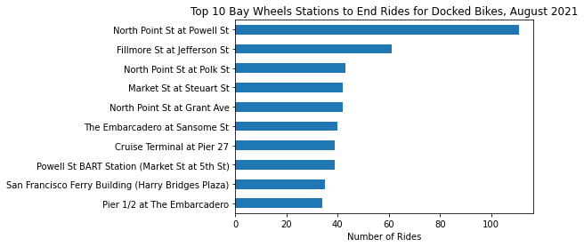

```python
top_end_stations.plot(kind='barh')
plt.title('Top 10 Bay Wheels Stations to End Rides for Docked Bikes, August 2021')
plt.xlabel('Number of Rides');
```

#### There is some overlap with the top 10 start stations for docked bikes. These include tourist spots such as North Point St., the Cruise Terminal and the Ferry Building, suggesting that docked bikes are ridden by tourists.

#### What were the Top 10 start stations for classic bikes?

```python
top_classic_stations= df_clean[df_clean["bike_type"]=="classic_bike"]["start_station_name"].\
value_counts().head(10).sort_values()
```

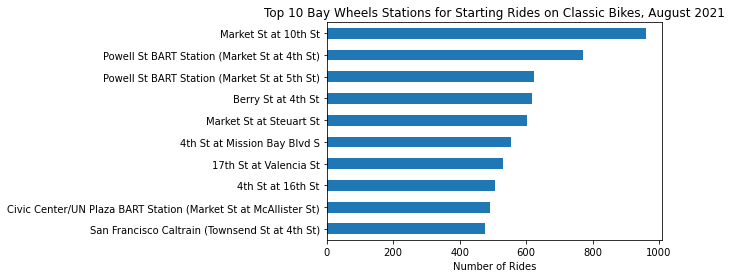

```python
top_classic_stations.plot(kind='barh')
plt.title('Top 10 Bay Wheels Stations for Starting Rides on Classic Bikes, August 2021')
plt.xlabel('Number of Rides');
```

#### The Top 10 start stations for classic bikes include downtown/financial district locations and commuter stations for BART and CalTrain.

#### What are the top 10 end stations for classic bikes?

```python
top_classic_end = df_clean[df_clean["bike_type"]=="classic_bike"]["end_station_name"].\
value_counts().head(10).sort_values()
```

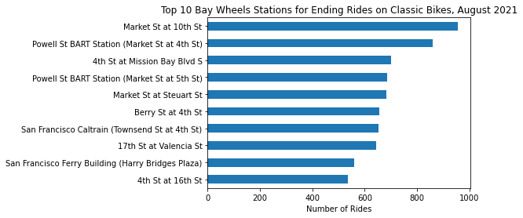

```python
top_classic_end.plot(kind='barh')
plt.title('Top 10 Bay Wheels Stations for Ending Rides on Classic Bikes, August 2021')
plt.xlabel('Number of Rides');
```

#### The Top 10 end stations for classic bikes include San Francisco downtown/financial district locations and commuter stations for BART, CalTrain and the ferries.

#### What were the Top 10 start stations for electric bikes?

```python
top_electric_stations= df_clean[df_clean["bike_type"]=="electric_bike"]["start_station_name"].\
value_counts().head(10).sort_values()
```

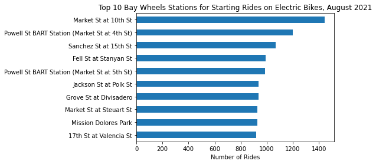

```python
top_electric_stations.plot(kind='barh')
plt.title('Top 10 Bay Wheels Stations for Starting Rides on Electric Bikes, August 2021')
plt.xlabel('Number of Rides');
```

#### What were the top 10 end stations for electric bikes?

```python
top_electric_end = df_clean[df_clean["bike_type"]=="electric_bike"]["end_station_name"].\
value_counts().head(10).sort_values()
```

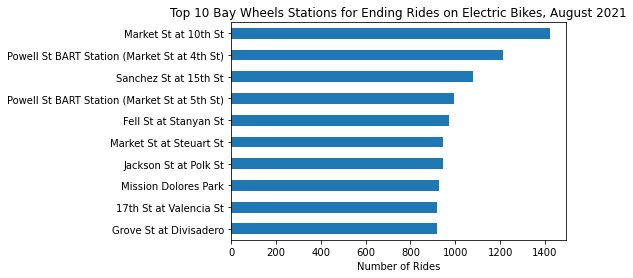

```python
top_electric_end.plot(kind='barh')
plt.title('Top 10 Bay Wheels Stations for Ending Rides on Electric Bikes, August 2021')
plt.xlabel('Number of Rides');
```

#### The Top 10 end stations for electric bikes include BART stations but also neighborhoods outside of downtown/financial district (Mission Dolores Park, 17th St. at Valencia).

#### Let's examine the top 10 start and end stations based on rider type (casual v. member)

#### What are the top 10 start stations for casual riders?

```python
top_casual_stations = df_clean[df_clean["rider_type"]=="casual"]["start_station_name"].\
value_counts().head(10).sort_values()
```

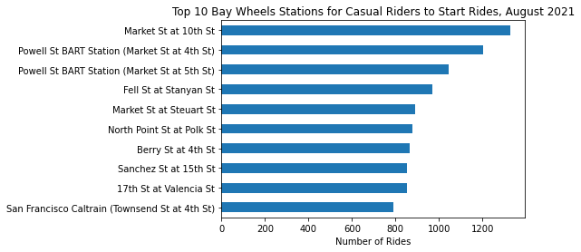

```python
top_casual_stations.plot(kind='barh')
plt.title('Top 10 Bay Wheels Stations for Casual Riders to Start Rides, August 2021')
plt.xlabel('Number of Rides');
```

#### The top 10 start stations for casual riders include transit stations (BART, Caltrain) as well as locations outside of the financial district/downtown (Sanchez St., 17th St., Fell St.)

#### What are the top 10 end stations for casual riders?

```python
top_casual_end = df_clean[df_clean["rider_type"]=="casual"]["end_station_name"].value_counts().head(10).sort_values()
```

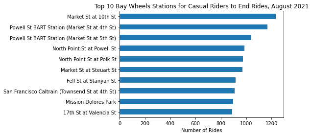

```python
top_casual_end.plot(kind='barh')
plt.title('Top 10 Bay Wheels Stations for Casual Riders to End Rides, August 2021')
plt.xlabel('Number of Rides');
```

#### What are the top 10 start stations for members?

```python
top_members_stations = df_clean[df_clean["rider_type"]=="member"]["start_station_name"].\
value_counts().head(10).sort_values()
```

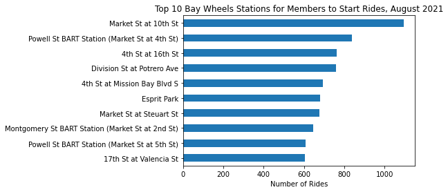

```python
top_members_stations.plot(kind='barh')
plt.title('Top 10 Bay Wheels Stations for Members to Start Rides, August 2021')
plt.xlabel('Number of Rides');
```

#### The top 10 start stations for members include neighborhoods outside of the financial district/downtown such as Division St. and Esprit Park and the UCSF Mission Bay campus (4th St).

#### What are the top 10 end stations for members?

```python
top_members_end= df_clean[df_clean["rider_type"]=="member"]["end_station_name"].value_counts().head(10).sort_values()
```

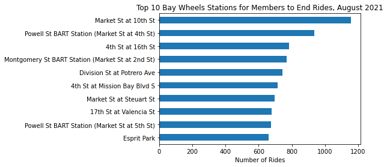

```python
top_members_end.plot(kind='barh')
plt.title('Top 10 Bay Wheels Stations for Members to End Rides, August 2021')
plt.xlabel('Number of Rides');
```

#### The top 10 end stations for members include neighborhoods outside of the financial district/downtown such as Division St. and Esprit Park and the UCSF Mission Bay campus (4th St).

#### There is some overlap in start stations between members and casual riders, although the member start stations include an additional BART (Bay Area Rapid Transit) station, suggesting that the bikes are ridden from BART to a final destination.

#### Let's take a look at the null values, especially the rows where "start_station_name" is null.

```python
#wondering what sort of bikes are ridden when start_station_name is null
df_clean[df_clean["start_station_name"].isnull()]["bike_type"].value_counts()
```

```
electric_bike    40212
classic_bike         0
docked_bike          0
Name: bike_type, dtype: int64
```

#### Electric bikes are ridden where start_station_name is null, which makes sense b/c electric bikes do not have to be parked/docked at a station.

```python
#wondering what sort of bikes are ridden when end_station_name is null
df_clean[df_clean["end_station_name"].isnull()]["bike_type"].value_counts()
```

```
electric_bike    43858
classic_bike       453
docked_bike          0
Name: bike_type, dtype: int64
```

#### When the end_station_name is null, almost all of the bikes are electric, and a few hundred are classic (and likely improperly parked).

```python
#examine those classic bike rides where end_station_name is null.
df_clean[(df_clean["bike_type"]=="classic_bike") & (df_clean["end_station_name"].isnull())]
```

|  | ride_id | bike_type | started_at | ended_at | start_station_name | start_station_id | end_station_name | end_station_id | start_lat | start_lng | end_lat | end_lng | rider_type |
| --- | --- | --- | --- | --- | --- | --- | --- | --- | --- | --- | --- | --- | --- |
| 1006 | 52A673C9CCF92540 | classic_bike | 2021-08-15 16:09:41 | 2021-08-15 23:00:08 | Howard St at 6th St | SF-I26- | NaN | NaN | 37.780265 | -122.406644 | NaN | NaN | casual |
| 1015 | 773CF762879729A0 | classic_bike | 2021-08-14 21:23:29 | 2021-08-15 22:23:16 | San Carlos St at Market St | SJ-N9 | NaN | NaN | 37.330698 | -121.888979 | NaN | NaN | casual |
| 1024 | 6086ED768E05A7C6 | classic_bike | 2021-08-20 09:27:07 | 2021-08-20 15:22:32 | Chestnut St at Van Ness Ave | SF-B22 | NaN | NaN | 37.802300 | -122.424413 | 37.76 | -122.42 | member |
| 4484 | 6EE4CEA370354677 | classic_bike | 2021-08-06 22:22:56 | 2021-08-07 23:22:50 | West Oakland BART Station | OK-N1 | NaN | NaN | 37.805189 | -122.294617 | NaN | NaN | member |
| 4510 | D149C4768331B369 | classic_bike | 2021-08-09 15:51:14 | 2021-08-10 07:38:47 | Montgomery St BART Station (Market St at 2nd St) | SF-F28-2 | NaN | NaN | 37.789620 | -122.400808 | 37.76 | -122.42 | member |
| ... | ... | ... | ... | ... | ... | ... | ... | ... | ... | ... | ... | ... | ... |
| 192778 | 718440AC03B8E4B5 | classic_bike | 2021-08-01 16:00:54 | 2021-08-01 16:30:28 | Yerba Buena Center for the Arts (Howard St at ... | SF-H27-1 | NaN | NaN | 37.784872 | -122.400876 | 37.81 | -122.42 | casual |
| 193218 | C23620123E6E8370 | classic_bike | 2021-08-27 05:42:17 | 2021-08-28 06:42:14 | McAllister St at Baker St | SF-J17 | NaN | NaN | 37.777416 | -122.441838 | NaN | NaN | casual |
| 197667 | 4B598CB7FAEFF13E | classic_bike | 2021-08-21 18:19:31 | 2021-08-22 19:19:23 | Vine St at Shattuck Ave | BK-A7 | NaN | NaN | 37.880222 | -122.269592 | NaN | NaN | casual |
| 201296 | 62AF74996C3B64DC | classic_bike | 2021-08-18 17:05:27 | 2021-08-19 07:23:00 | 3rd St at Townsend St | SF-J29-1 | NaN | NaN | 37.778588 | -122.392553 | NaN | NaN | casual |
| 201786 | 86E32D59B76557D4 | classic_bike | 2021-08-14 13:37:36 | 2021-08-14 14:56:41 | Embarcadero BART Station (Beale St at Market St) | SF-E29-3 | NaN | NaN | 37.792251 | -122.397086 | 37.78 | -122.40 | casual |

453 rows × 13 columns

#### Some of these classic bike rides where end_station_name are null are also missing the end_lat and end_lng values. They might be bikes that were dumped/stolen/lost.

```python
#examine the rows where "end_lat" is null. There are 276 such rows, according to info()
df_clean[df_clean["end_lat"].isnull()]
```

|  | ride_id | bike_type | started_at | ended_at | start_station_name | start_station_id | end_station_name | end_station_id | start_lat | start_lng | end_lat | end_lng | rider_type |
| --- | --- | --- | --- | --- | --- | --- | --- | --- | --- | --- | --- | --- | --- |
| 1006 | 52A673C9CCF92540 | classic_bike | 2021-08-15 16:09:41 | 2021-08-15 23:00:08 | Howard St at 6th St | SF-I26- | NaN | NaN | 37.780265 | -122.406644 | NaN | NaN | casual |
| 1015 | 773CF762879729A0 | classic_bike | 2021-08-14 21:23:29 | 2021-08-15 22:23:16 | San Carlos St at Market St | SJ-N9 | NaN | NaN | 37.330698 | -121.888979 | NaN | NaN | casual |
| 4484 | 6EE4CEA370354677 | classic_bike | 2021-08-06 22:22:56 | 2021-08-07 23:22:50 | West Oakland BART Station | OK-N1 | NaN | NaN | 37.805189 | -122.294617 | NaN | NaN | member |
| 4511 | 62AD00B99D2C65DB | classic_bike | 2021-08-12 17:59:28 | 2021-08-13 09:59:25 | Montgomery St BART Station (Market St at 2nd St) | SF-F28-2 | NaN | NaN | 37.789620 | -122.400808 | NaN | NaN | member |
| 4644 | 64CC97D950BFE570 | classic_bike | 2021-08-30 15:16:38 | 2021-08-31 16:16:33 | 23rd Ave at Clement St | SF-G7 | NaN | NaN | 37.781929 | -122.482786 | NaN | NaN | casual |
| ... | ... | ... | ... | ... | ... | ... | ... | ... | ... | ... | ... | ... | ... |
| 192657 | 22417E7562FEE466 | classic_bike | 2021-08-18 19:36:57 | 2021-08-19 20:36:51 | Yerba Buena Center for the Arts (Howard St at ... | SF-H27-1 | NaN | NaN | 37.784872 | -122.400876 | NaN | NaN | casual |
| 192718 | 6A4ACC2B9D68841F | classic_bike | 2021-08-08 11:44:42 | 2021-08-08 17:13:43 | Pierce St at Haight St | SF-K20 | NaN | NaN | 37.771793 | -122.433708 | NaN | NaN | casual |
| 193218 | C23620123E6E8370 | classic_bike | 2021-08-27 05:42:17 | 2021-08-28 06:42:14 | McAllister St at Baker St | SF-J17 | NaN | NaN | 37.777416 | -122.441838 | NaN | NaN | casual |
| 197667 | 4B598CB7FAEFF13E | classic_bike | 2021-08-21 18:19:31 | 2021-08-22 19:19:23 | Vine St at Shattuck Ave | BK-A7 | NaN | NaN | 37.880222 | -122.269592 | NaN | NaN | casual |
| 201296 | 62AF74996C3B64DC | classic_bike | 2021-08-18 17:05:27 | 2021-08-19 07:23:00 | 3rd St at Townsend St | SF-J29-1 | NaN | NaN | 37.778588 | -122.392553 | NaN | NaN | casual |

276 rows × 13 columns

#### This is a relatively small number of null values compared to the rest of the dataset. Let's confirm that the rows where end_lat is null also have null values for end_station_name and end_station_id.

```python
mask = df_clean["end_station_name"].isnull() & df_clean["end_station_id"].isnull() & df_clean["end_lat"].isnull()
df_clean[mask]
```

|  | ride_id | bike_type | started_at | ended_at | start_station_name | start_station_id | end_station_name | end_station_id | start_lat | start_lng | end_lat | end_lng | rider_type |
| --- | --- | --- | --- | --- | --- | --- | --- | --- | --- | --- | --- | --- | --- |
| 1006 | 52A673C9CCF92540 | classic_bike | 2021-08-15 16:09:41 | 2021-08-15 23:00:08 | Howard St at 6th St | SF-I26- | NaN | NaN | 37.780265 | -122.406644 | NaN | NaN | casual |
| 1015 | 773CF762879729A0 | classic_bike | 2021-08-14 21:23:29 | 2021-08-15 22:23:16 | San Carlos St at Market St | SJ-N9 | NaN | NaN | 37.330698 | -121.888979 | NaN | NaN | casual |
| 4484 | 6EE4CEA370354677 | classic_bike | 2021-08-06 22:22:56 | 2021-08-07 23:22:50 | West Oakland BART Station | OK-N1 | NaN | NaN | 37.805189 | -122.294617 | NaN | NaN | member |
| 4511 | 62AD00B99D2C65DB | classic_bike | 2021-08-12 17:59:28 | 2021-08-13 09:59:25 | Montgomery St BART Station (Market St at 2nd St) | SF-F28-2 | NaN | NaN | 37.789620 | -122.400808 | NaN | NaN | member |
| 4644 | 64CC97D950BFE570 | classic_bike | 2021-08-30 15:16:38 | 2021-08-31 16:16:33 | 23rd Ave at Clement St | SF-G7 | NaN | NaN | 37.781929 | -122.482786 | NaN | NaN | casual |
| ... | ... | ... | ... | ... | ... | ... | ... | ... | ... | ... | ... | ... | ... |
| 192657 | 22417E7562FEE466 | classic_bike | 2021-08-18 19:36:57 | 2021-08-19 20:36:51 | Yerba Buena Center for the Arts (Howard St at ... | SF-H27-1 | NaN | NaN | 37.784872 | -122.400876 | NaN | NaN | casual |
| 192718 | 6A4ACC2B9D68841F | classic_bike | 2021-08-08 11:44:42 | 2021-08-08 17:13:43 | Pierce St at Haight St | SF-K20 | NaN | NaN | 37.771793 | -122.433708 | NaN | NaN | casual |
| 193218 | C23620123E6E8370 | classic_bike | 2021-08-27 05:42:17 | 2021-08-28 06:42:14 | McAllister St at Baker St | SF-J17 | NaN | NaN | 37.777416 | -122.441838 | NaN | NaN | casual |
| 197667 | 4B598CB7FAEFF13E | classic_bike | 2021-08-21 18:19:31 | 2021-08-22 19:19:23 | Vine St at Shattuck Ave | BK-A7 | NaN | NaN | 37.880222 | -122.269592 | NaN | NaN | casual |
| 201296 | 62AF74996C3B64DC | classic_bike | 2021-08-18 17:05:27 | 2021-08-19 07:23:00 | 3rd St at Townsend St | SF-J29-1 | NaN | NaN | 37.778588 | -122.392553 | NaN | NaN | casual |

276 rows × 13 columns

```python
len(df_clean[mask]) #confirmed
```

```
276
```

#### It looks like these rides where end_lat (and end_lng and end_station_name and end_station_id) is null includes classic bikes. According to Lyft, classic bikes must be returned to a bike station, which would indicate that these classic bikes were not properly parked at bike stations when the rides ended. In other words, they were dumped or lost.

```python
#Let's confirm what kind of bikes were ridden where end_lat is null.
df_clean[df_clean["end_lat"].isnull()]["bike_type"].value_counts()
```

```
classic_bike     276
docked_bike        0
electric_bike      0
Name: bike_type, dtype: int64
```

#### Only classic bikes were ridden where the end_lat was null.

```python
#Let's see what kind of riders were riding where end_lat is null.
df_clean[df_clean["end_lat"].isnull()]["rider_type"].value_counts()
```

```
casual    217
member     59
Name: rider_type, dtype: int64
```

#### The majority of riders where end_lat is null were casual (non-member) riders.

#### Rows where end_lat is null also have null values for end_station_name, end_station_id and end_lng. Given the relatively small number of rides where end_lat is null compared to the entire dataset, we'll drop these rows.

```python
#drop rows where "end_lat" is null
df_clean = df_clean[df_clean["end_lat"].notnull()]
```

```python
df_clean.info() #checking
```

```
<class 'pandas.core.frame.DataFrame'>
Int64Index: 206747 entries, 0 to 207022
Data columns (total 13 columns):
 #   Column              Non-Null Count   Dtype
---  ------              --------------   -----
 0   ride_id             206747 non-null  object
 1   bike_type           206747 non-null  category
 2   started_at          206747 non-null  object
 3   ended_at            206747 non-null  object
 4   start_station_name  166535 non-null  object
 5   start_station_id    166535 non-null  object
 6   end_station_name    162712 non-null  object
 7   end_station_id      162712 non-null  object
 8   start_lat           206747 non-null  float64
 9   start_lng           206747 non-null  float64
 10  end_lat             206747 non-null  float64
 11  end_lng             206747 non-null  float64
 12  rider_type          206747 non-null  category
dtypes: category(2), float64(4), object(7)
memory usage: 19.3+ MB
```

#### Let's examine the rows where start_station_name is null.

```python
df_clean[df_clean["start_station_name"].isnull()]["bike_type"].value_counts()
```

```
electric_bike    40212
classic_bike         0
docked_bike          0
Name: bike_type, dtype: int64
```

#### Only electric bikes were ridden when the start_station_name is null, which makes sense b/c electric bikes aren't required to be docked at a station. Let's see what kind of riders these were.

```python
df_clean[df_clean["start_station_name"].isnull()]["rider_type"].value_counts()
```

```
casual    24691
member    15521
Name: rider_type, dtype: int64
```

#### More riders were casual riders where the start_station_name is null, which makes some sense since there are more casual riders than members riding in August 2021.

#### Let's see what type of bikes were ridden where the end station name is null.

```python
df_clean[df_clean["end_station_name"].isnull()]["bike_type"].value_counts()
```

```
electric_bike    43858
classic_bike       177
docked_bike          0
Name: bike_type, dtype: int64
```

#### A small number classic bikes were ridden where the end station is a null value, indicating that the bike was not properly returned to a station (as is required by Lyft).

#### Let's see the type of riders where the end station name is null.

```python
df_clean[df_clean["end_station_name"].isnull()]["rider_type"].value_counts()
```

```
casual    29907
member    14128
Name: rider_type, dtype: int64
```

#### In August 2021, more riders were casual riders where the end_station_name is null. But overall, there are more casual riders than members riding in August 2021.

#### I am replacing the null values in start_station_name, start_station_id, end_station_name, end_station_id with the string "Unavailable." I did not want to just drop the rows where any of these values were null because there were 44,000 rows, and deleting that many rows (about 20 percent of the dataset) was going to impact the analysis.

```python
values = {"start_station_name": "Unavailable", "start_station_id": "Unavailable", "end_station_name": "Unavailable", "end_station_id": "Unavailable"}
df_clean.fillna(value=values, inplace=True)
```

#### To expand our analysis, we'll need the calculate the time duration of rides. To facilitate my analysis of the time duration of rides, I converted the started_at and ended_at values to datetime objects and then created a new column, "ride_duration", which is the time duration in minutes.

```python
#convert "started_at" to datetime object
from datetime import datetime

df_clean['started_at'] = df_clean['started_at'].apply(lambda x: datetime.strptime(x, '%Y-%m-%d %H:%M:%S'))
```

```python
#convert "ended_at" to datetime object
df_clean['ended_at'] = df_clean['ended_at'].apply(lambda x: datetime.strptime(x, '%Y-%m-%d %H:%M:%S'))
```

```python
#create a new column, "ride_duration", which is the difference in minutes
#between ended_at and started_at
from dateutil.relativedelta import relativedelta
from datetime import date

#calculate the difference in minutes between when a ride started and when it ended.
df_clean["ride_duration"] = df_clean['ended_at'] - df_clean['started_at']
df_clean["ride_duration"]=df_clean["ride_duration"]/np.timedelta64(1,'m')
```

```python
#rearrange the columns to move ride_duration closer to "started_at"
cols = df_clean.columns
```

```python
cols
```

```
Index(['ride_id', 'bike_type', 'started_at', 'ended_at', 'start_station_name',
       'start_station_id', 'end_station_name', 'end_station_id', 'start_lat',
       'start_lng', 'end_lat', 'end_lng', 'rider_type', 'ride_duration'],
      dtype='object')
```

```python
cols = ['ride_id', 'bike_type', 'ride_duration', 'started_at', 'ended_at',
       'start_station_name', 'start_station_id', 'end_station_name',
       'end_station_id', 'start_lat', 'start_lng', 'end_lat', 'end_lng',
       'rider_type']
```

```python
df_clean = df_clean[cols]
```

```python
df_clean["ride_duration"].describe() #apply describe to ride_duration
```

```
count    206747.000000
mean         16.560701
std          76.828137
min          -2.883333
25%           6.383333
50%          10.733333
75%          17.483333
max       13711.533333
Name: ride_duration, dtype: float64
```

#### A negative minimum value for ride_duration indicates there's a problem with some of the data and that some cleaning needs to be done.

```python
#examine the rows where ride_duration is negative or zero.
df_clean[df_clean["ride_duration"] <= 0]
```

|  | ride_id | bike_type | ride_duration | started_at | ended_at | start_station_name | start_station_id | end_station_name | end_station_id | start_lat | start_lng | end_lat | end_lng | rider_type |
| --- | --- | --- | --- | --- | --- | --- | --- | --- | --- | --- | --- | --- | --- | --- |
| 2949 | 5D17AE4971878762 | electric_bike | 0.000000 | 2021-08-02 21:35:20 | 2021-08-02 21:35:20 | 22nd St Caltrain Station | SF-P30 | 22nd St Caltrain Station | SF-P30 | 37.757678 | -122.391961 | 37.757654 | -122.391940 | casual |
| 7043 | 924385CCDC8AF804 | electric_bike | -0.033333 | 2021-08-28 11:04:33 | 2021-08-28 11:04:31 | The Embarcadero at Sansome St | SF-A27 | The Embarcadero at Sansome St | SF-A27 | 37.804783 | -122.403359 | 37.804806 | -122.403362 | member |
| 11672 | 7947DFCA39279AF5 | classic_bike | 0.000000 | 2021-08-15 13:58:55 | 2021-08-15 13:58:55 | S Park St at 3rd St | SF-I29-2 | S Park St at 3rd St | SF-I29-2 | 37.780760 | -122.394989 | 37.780760 | -122.394989 | member |
| 17607 | 22ECA866EE266446 | classic_bike | -0.016667 | 2021-08-31 21:00:01 | 2021-08-31 21:00:00 | 7th Ave at Clement St | SF-G12 | 7th Ave at Clement St | SF-G12 | 37.782439 | -122.465377 | 37.782439 | -122.465377 | member |
| 17667 | 98F57167E5EFCC3D | electric_bike | 0.000000 | 2021-08-13 10:43:37 | 2021-08-13 10:43:37 | Ryland Park | SJ-K9 | Ryland Park | SJ-K9 | 37.342758 | -121.895668 | 37.342768 | -121.895672 | member |
| 27970 | 9313D4305D6083E4 | classic_bike | 0.000000 | 2021-08-04 16:48:25 | 2021-08-04 16:48:25 | Duboce Park | SF-L19 | Duboce Park | SF-L19 | 37.769223 | -122.434062 | 37.769223 | -122.434062 | casual |
| 36196 | 1063217F8793D95A | classic_bike | 0.000000 | 2021-08-18 13:12:38 | 2021-08-18 13:12:38 | Davis St at Jackson St | SF-D28 | Davis St at Jackson St | SF-D28 | 37.797280 | -122.398436 | 37.797280 | -122.398436 | member |
| 50590 | CA087EE65647EE38 | classic_bike | 0.000000 | 2021-08-28 02:29:06 | 2021-08-28 02:29:06 | Harrison St at 20th St | SF-P24 | Harrison St at 20th St | SF-P24 | 37.758862 | -122.412544 | 37.758862 | -122.412544 | member |
| 63781 | 9324CB2FD1EFEE53 | electric_bike | 0.000000 | 2021-08-17 21:21:00 | 2021-08-17 21:21:00 | The Embarcadero at Pier 38 | SF-H30 | Unavailable | Unavailable | 37.783127 | -122.387987 | 37.780000 | -122.390000 | casual |
| 94896 | F06C69799DF0C7CD | classic_bike | 0.000000 | 2021-08-16 17:55:37 | 2021-08-16 17:55:37 | Battery St at Filbert St | SF-B28-2 | Battery St at Filbert St | SF-B28-2 | 37.802055 | -122.401715 | 37.802055 | -122.401715 | member |
| 100964 | CFC2B773E2ED8DB4 | electric_bike | 0.000000 | 2021-08-13 17:27:05 | 2021-08-13 17:27:05 | Jersey St at Church St | SF-R20 | Jersey St at Church St | SF-R20 | 37.750888 | -122.427690 | 37.750899 | -122.427696 | casual |
| 102187 | 47118B4E5E4061E2 | electric_bike | 0.000000 | 2021-08-25 11:00:36 | 2021-08-25 11:00:36 | Hyde St at Post St | SF-G24 | Hyde St at Post St | SF-G24 | 37.786901 | -122.416567 | 37.786977 | -122.416588 | member |
| 104033 | 545123A50BC701AB | electric_bike | 0.000000 | 2021-08-13 19:55:42 | 2021-08-13 19:55:42 | Webster St at Clay St | SF-E20 | Unavailable | Unavailable | 37.790466 | -122.432581 | 37.790000 | -122.430000 | member |
| 119810 | 6C7A63E6D93D6BC1 | classic_bike | 0.000000 | 2021-08-18 09:53:49 | 2021-08-18 09:53:49 | Derby St at College Ave | BK-F10 | Derby St at College Ave | BK-F10 | 37.861804 | -122.253569 | 37.861804 | -122.253569 | casual |
| 131238 | 06AA26F57C928F26 | electric_bike | 0.000000 | 2021-08-16 17:41:47 | 2021-08-16 17:41:47 | Mission Bay Kids Park | SF-L29 | Mission Bay Kids Park | SF-L29 | 37.772405 | -122.392805 | 37.772386 | -122.392794 | member |
| 136129 | C1A862723457BB5F | electric_bike | -2.883333 | 2021-08-13 17:11:37 | 2021-08-13 17:08:44 | Unavailable | Unavailable | Koshland Park | SF-K21 | 37.770000 | -122.430000 | 37.773482 | -122.427136 | casual |
| 142230 | FBFFE82641581A7B | classic_bike | 0.000000 | 2021-08-15 14:46:53 | 2021-08-15 14:46:53 | Folsom St at 9th St | SF-K25 | Folsom St at 9th St | SF-K25 | 37.773717 | -122.411647 | 37.773717 | -122.411647 | member |
| 148962 | 9F43201C50AC9784 | classic_bike | -0.016667 | 2021-08-13 19:50:42 | 2021-08-13 19:50:41 | Howard St at 8th St | SF-J25 | Howard St at 8th St | SF-J25 | 37.776513 | -122.411306 | 37.776513 | -122.411306 | member |
| 163018 | 578691B7BA76E198 | electric_bike | 0.000000 | 2021-08-12 17:22:09 | 2021-08-12 17:22:09 | Bay St at Fillmore St | SF-B19 | Unavailable | Unavailable | 37.802622 | -122.436091 | 37.800000 | -122.440000 | casual |
| 169738 | F9CAC20D37135863 | electric_bike | 0.000000 | 2021-08-06 19:05:25 | 2021-08-06 19:05:25 | Pier 1/2 at The Embarcadero | SF-D29 | Unavailable | Unavailable | 37.796468 | -122.394624 | 37.800000 | -122.390000 | casual |
| 170136 | C292F06726090868 | electric_bike | 0.000000 | 2021-08-27 18:37:00 | 2021-08-27 18:37:00 | Mission Dolores Park | SF-O21 | Unavailable | Unavailable | 37.761372 | -122.426648 | 37.760000 | -122.430000 | member |
| 170170 | 573D280373E9E94C | electric_bike | 0.000000 | 2021-08-11 19:48:42 | 2021-08-11 19:48:42 | Mission Dolores Park | SF-O21 | Unavailable | Unavailable | 37.761338 | -122.426671 | 37.760000 | -122.430000 | member |
| 173666 | EE58996FA6865D74 | electric_bike | 0.000000 | 2021-08-29 09:05:40 | 2021-08-29 09:05:40 | Guerrero Park | SF-S22-2 | Unavailable | Unavailable | 37.745756 | -122.422136 | 37.750000 | -122.420000 | casual |
| 174115 | FEDA7D1249ACC0A0 | electric_bike | 0.000000 | 2021-08-03 09:00:00 | 2021-08-03 09:00:00 | Harrison St at 20th St | SF-P24 | Unavailable | Unavailable | 37.758894 | -122.412608 | 37.760000 | -122.410000 | casual |
| 174185 | 3C4D15AF577286FD | electric_bike | 0.000000 | 2021-08-21 17:30:27 | 2021-08-21 17:30:27 | San Francisco Caltrain Station (King St at 4th... | SF-J29-3 | Unavailable | Unavailable | 37.776319 | -122.394436 | 37.780000 | -122.390000 | casual |
| 174467 | E2C8BA127ECFD14B | electric_bike | 0.000000 | 2021-08-10 16:03:34 | 2021-08-10 16:03:34 | 4th St at 16th St | SF-M30 | Unavailable | Unavailable | 37.767202 | -122.390682 | 37.770000 | -122.390000 | casual |
| 174991 | 912893835075FC12 | electric_bike | 0.000000 | 2021-08-25 19:12:26 | 2021-08-25 19:12:26 | Montgomery St BART Station (Market St at 2nd St) | SF-F28-2 | Unavailable | Unavailable | 37.790681 | -122.402136 | 37.790000 | -122.400000 | casual |
| 175645 | B03C081EE504F4AE | classic_bike | 0.000000 | 2021-08-16 14:44:04 | 2021-08-16 14:44:04 | 7th St at King St | SF-L27-2 | Unavailable | Unavailable | 37.771229 | -122.400886 | 37.770000 | -122.400000 | casual |
| 176919 | EAFA9B73FFD2784B | electric_bike | 0.000000 | 2021-08-14 12:08:40 | 2021-08-14 12:08:40 | Berry St at 4th St | SF-K29-1 | Unavailable | Unavailable | 37.775923 | -122.393327 | 37.780000 | -122.390000 | member |
| 178180 | 247EA050E2D265B4 | electric_bike | 0.000000 | 2021-08-31 15:45:19 | 2021-08-31 15:45:19 | Julian St at The Alameda | SJ-K5 | Unavailable | Unavailable | 37.332336 | -121.912267 | 37.330000 | -121.910000 | member |
| 194684 | 3D8032FC29DBFA41 | electric_bike | -0.683333 | 2021-08-30 07:22:07 | 2021-08-30 07:21:26 | Unavailable | Unavailable | Unavailable | Unavailable | 37.750000 | -122.420000 | 37.750000 | -122.420000 | member |
| 205460 | ABECB1472F930562 | classic_bike | 0.000000 | 2021-08-21 18:39:38 | 2021-08-21 18:39:38 | McAllister St at Baker St | SF-J17 | McAllister St at Baker St | SF-J17 | 37.777416 | -122.441838 | 37.777416 | -122.441838 | member |
| 205516 | E1ADDFAE4A3E10A1 | electric_bike | 0.000000 | 2021-08-25 18:37:22 | 2021-08-25 18:37:22 | Page St at Scott St | SF-K19 | Page St at Scott St | SF-K19 | 37.772374 | -122.435689 | 37.772403 | -122.435713 | member |

#### How many rides where the duration was 0 minutes or less?

```python
len(df_clean[df_clean["ride_duration"]<=0]) #there are 28 rides where the duration is 0.
```

```
33
```

#### There are 33 rows with rides of 0 minutes or less, so we'll drop these.

```python
#drop the rows with zero ride_duration
df_clean= df_clean[~(df_clean["ride_duration"] <=0)]
```

```python
df_clean["ride_duration"].describe() #check
```

```
count    206714.000000
mean         16.563362
std          76.833980
min           0.016667
25%           6.383333
50%          10.733333
75%          17.495833
max       13711.533333
Name: ride_duration, dtype: float64
```

#### There are rides that are less than a minute! Let's examine the rides that 1 minute or less.

```python
df_clean[df_clean["ride_duration"] <= 1].sort_values(by= "ride_duration", ascending=True)
```

|  | ride_id | bike_type | ride_duration | started_at | ended_at | start_station_name | start_station_id | end_station_name | end_station_id | start_lat | start_lng | end_lat | end_lng | rider_type |
| --- | --- | --- | --- | --- | --- | --- | --- | --- | --- | --- | --- | --- | --- | --- |
| 38176 | EAE8801F79B00DEA | classic_bike | 0.016667 | 2021-08-06 14:28:50 | 2021-08-06 14:28:51 | Market St at Steuart St | SF-E29-2 | Market St at Steuart St | SF-E29-2 | 37.794525 | -122.394880 | 37.794525 | -122.394880 | member |
| 165156 | 1019B5F0D7DFE571 | electric_bike | 0.016667 | 2021-08-02 14:21:58 | 2021-08-02 14:21:59 | 22nd St at Dolores St | SF-Q21-1 | Unavailable | Unavailable | 37.755020 | -122.425720 | 37.760000 | -122.430000 | casual |
| 92481 | B224F0FB9E8215B8 | classic_bike | 0.016667 | 2021-08-12 19:03:22 | 2021-08-12 19:03:23 | 17th St at Dolores St | SF-N21 | 17th St at Dolores St | SF-N21 | 37.763015 | -122.426497 | 37.763015 | -122.426497 | member |
| 165360 | CDB324C7AC8E25DA | electric_bike | 0.016667 | 2021-08-12 07:21:50 | 2021-08-12 07:21:51 | Precita Park | SF-S24 | Unavailable | Unavailable | 37.747273 | -122.411401 | 37.750000 | -122.410000 | casual |
| 117152 | B61D69823EC0B1C3 | electric_bike | 0.016667 | 2021-08-29 16:54:36 | 2021-08-29 16:54:37 | Indiana St at Cesar Chavez St | SF-S29 | Indiana St at Cesar Chavez St | SF-S29 | 37.750436 | -122.390616 | 37.750416 | -122.390497 | member |
| ... | ... | ... | ... | ... | ... | ... | ... | ... | ... | ... | ... | ... | ... | ... |
| 71009 | 43C806C7151AA623 | electric_bike | 1.000000 | 2021-08-05 12:43:23 | 2021-08-05 12:44:23 | Unavailable | Unavailable | Arguello Blvd at Edward St | SF-H13 | 37.780000 | -122.460000 | 37.778673 | -122.458624 | member |
| 190405 | 9FE719267064FA16 | electric_bike | 1.000000 | 2021-08-26 22:00:18 | 2021-08-26 22:01:18 | Unavailable | Unavailable | Unavailable | Unavailable | 37.710000 | -122.430000 | 37.710000 | -122.430000 | member |
| 3744 | EF68EC0D2ED82EE6 | electric_bike | 1.000000 | 2021-08-30 09:38:55 | 2021-08-30 09:39:55 | Post St at Divisadero St | SF-G18 | Post St at Divisadero St | SF-G18 | 37.784413 | -122.439272 | 37.784425 | -122.439347 | member |
| 159445 | B003D60B406AA16C | electric_bike | 1.000000 | 2021-08-03 08:09:40 | 2021-08-03 08:10:40 | Unavailable | Unavailable | Webster St at O'Farrell St | SF-H20 | 37.780000 | -122.430000 | 37.783383 | -122.431126 | member |
| 179868 | 92B09DFEA79275FB | electric_bike | 1.000000 | 2021-08-14 19:30:29 | 2021-08-14 19:31:29 | Unavailable | Unavailable | Unavailable | Unavailable | 37.340000 | -121.890000 | 37.340000 | -121.890000 | member |

4716 rows × 14 columns

#### There are rides 1 minute or less where the start and end station are different. However, there are also rides where the start and end station are the same, and most likely the rider checked out the bike and returned it or had a technical glitch.

```python
#examine rides where start and end stations are different and ride duration is 1 or less
df_clean[(df_clean["ride_duration"]<=1) &(df_clean["start_station_name"]!=\
                                           df_clean["end_station_name"])]
```

|  | ride_id | bike_type | ride_duration | started_at | ended_at | start_station_name | start_station_id | end_station_name | end_station_id | start_lat | start_lng | end_lat | end_lng | rider_type |
| --- | --- | --- | --- | --- | --- | --- | --- | --- | --- | --- | --- | --- | --- | --- |
| 1028 | 702C53CD380B5353 | electric_bike | 0.433333 | 2021-08-26 16:13:02 | 2021-08-26 16:13:28 | 17th & Folsom Street Park (17th St at Folsom St) | SF-N23 | Unavailable | Unavailable | 37.763752 | -122.415475 | 37.760000 | -122.420000 | member |
| 2306 | 772E1C5A349BABE3 | electric_bike | 0.733333 | 2021-08-22 16:14:44 | 2021-08-22 16:15:28 | 30th St at San Jose Ave | SF-T21 | 29th St at Tiffany Ave | SF-T22 | 37.742326 | -122.422946 | 37.744060 | -122.421481 | member |
| 4469 | 76AAAC4268ED3833 | electric_bike | 0.183333 | 2021-08-12 21:48:37 | 2021-08-12 21:48:48 | 2nd St at Townsend St | SF-I30 | Unavailable | Unavailable | 37.780392 | -122.390048 | 37.780000 | -122.390000 | casual |
| 4487 | 5D36576D646E724A | electric_bike | 0.250000 | 2021-08-07 17:27:28 | 2021-08-07 17:27:43 | Hubbell St at 16th St | SF-M28 | Unavailable | Unavailable | 37.766669 | -122.398129 | 37.770000 | -122.400000 | member |
| 4642 | 740DCC49F299121B | electric_bike | 0.733333 | 2021-08-21 21:47:40 | 2021-08-21 21:48:24 | 3rd St at Keyes St | SJ-Q10 | Unavailable | Unavailable | 37.320927 | -121.876356 | 37.320000 | -121.880000 | member |
| ... | ... | ... | ... | ... | ... | ... | ... | ... | ... | ... | ... | ... | ... | ... |
| 205726 | 86F0EC27E2B1ABE8 | electric_bike | 0.766667 | 2021-08-17 16:19:55 | 2021-08-17 16:20:41 | Unavailable | Unavailable | Page St at Scott St | SF-K19 | 37.770000 | -122.440000 | 37.772338 | -122.435834 | member |
| 205727 | F6215F951DF5BE84 | electric_bike | 0.700000 | 2021-08-17 16:16:51 | 2021-08-17 16:17:33 | Unavailable | Unavailable | Page St at Scott St | SF-K19 | 37.770000 | -122.440000 | 37.772340 | -122.435997 | member |
| 205776 | 91A62F9A1F3CB8D1 | electric_bike | 0.200000 | 2021-08-18 12:12:58 | 2021-08-18 12:13:10 | Unavailable | Unavailable | Page St at Scott St | SF-K19 | 37.770000 | -122.440000 | 37.772374 | -122.435859 | member |
| 205901 | E025D2B3C4BD2DC6 | electric_bike | 0.966667 | 2021-08-02 12:41:31 | 2021-08-02 12:42:29 | Unavailable | Unavailable | McAllister St at Baker St | SF-J17 | 37.770000 | -122.440000 | 37.777377 | -122.441938 | member |
| 206693 | 583986F427D3CC91 | electric_bike | 1.000000 | 2021-08-11 16:58:33 | 2021-08-11 16:59:33 | Pierce St at Haight St | SF-K20 | Page St at Scott St | SF-K19 | 37.771812 | -122.433745 | 37.772377 | -122.435732 | member |

700 rows × 14 columns

#### There are 700 rides that are less or equal than 1 minute where the start and end station are different. Let's look at rides that are 1 minute or less where start and end stations are the same.

```python
df_clean[(df_clean["ride_duration"]<=1) & \
                      (df_clean["start_station_name"]==df_clean["end_station_name"])]
```

|  | ride_id | bike_type | ride_duration | started_at | ended_at | start_station_name | start_station_id | end_station_name | end_station_id | start_lat | start_lng | end_lat | end_lng | rider_type |
| --- | --- | --- | --- | --- | --- | --- | --- | --- | --- | --- | --- | --- | --- | --- |
| 1 | EA6D1C08FB8D1751 | classic_bike | 0.033333 | 2021-08-16 18:34:12 | 2021-08-16 18:34:14 | 7th Ave at Cabrillo St | SF-J12 | 7th Ave at Cabrillo St | SF-J12 | 37.775120 | -122.464998 | 37.775120 | -122.464998 | member |
| 38 | 3C86493CBF396410 | docked_bike | 0.966667 | 2021-08-10 13:01:38 | 2021-08-10 13:02:36 | 7th Ave at Cabrillo St | SF-J12 | 7th Ave at Cabrillo St | SF-J12 | 37.775121 | -122.464998 | 37.775121 | -122.464998 | casual |
| 64 | CC646936A42B3663 | classic_bike | 0.800000 | 2021-08-25 13:44:18 | 2021-08-25 13:45:06 | The Embarcadero at Sansome St | SF-A27 | The Embarcadero at Sansome St | SF-A27 | 37.804770 | -122.403234 | 37.804770 | -122.403234 | member |
| 65 | BF44ECCEA0C18A54 | classic_bike | 0.350000 | 2021-08-30 23:06:31 | 2021-08-30 23:06:52 | San Fernando St at 4th St | SJ-M10-2 | San Fernando St at 4th St | SJ-M10-2 | 37.335885 | -121.885660 | 37.335885 | -121.885660 | member |
| 130 | EDD1A10339E490C9 | classic_bike | 0.116667 | 2021-08-18 20:16:19 | 2021-08-18 20:16:26 | Rockridge BART Station | OK-B4 | Rockridge BART Station | OK-B4 | 37.844279 | -122.251900 | 37.844279 | -122.251900 | member |
| ... | ... | ... | ... | ... | ... | ... | ... | ... | ... | ... | ... | ... | ... | ... |
| 206964 | CAB7C6E765533339 | classic_bike | 0.966667 | 2021-08-07 11:24:42 | 2021-08-07 11:25:40 | Page St at Scott St | SF-K19 | Page St at Scott St | SF-K19 | 37.772354 | -122.435857 | 37.772354 | -122.435857 | casual |
| 206976 | F79787649809730D | classic_bike | 0.233333 | 2021-08-24 09:11:37 | 2021-08-24 09:11:51 | McAllister St at Baker St | SF-J17 | McAllister St at Baker St | SF-J17 | 37.777416 | -122.441838 | 37.777416 | -122.441838 | casual |
| 206979 | AB710AE231DC91C1 | electric_bike | 0.783333 | 2021-08-02 16:07:20 | 2021-08-02 16:08:07 | Page St at Scott St | SF-K19 | Page St at Scott St | SF-K19 | 37.772355 | -122.435761 | 37.772365 | -122.435772 | casual |
| 206983 | A2F4096DBDEF73D1 | electric_bike | 0.550000 | 2021-08-10 16:44:42 | 2021-08-10 16:45:15 | Post St at Kearny St | SF-F27 | Post St at Kearny St | SF-F27 | 37.788962 | -122.403274 | 37.788939 | -122.403267 | casual |
| 207012 | AD5E2AFC09EECB9A | electric_bike | 0.666667 | 2021-08-22 07:10:53 | 2021-08-22 07:11:33 | McAllister St at Baker St | SF-J17 | McAllister St at Baker St | SF-J17 | 37.777375 | -122.441954 | 37.777386 | -122.441943 | member |

4016 rows × 14 columns

#### There are 4016 rides that are 1 minute or less where the start and end stations are the same. These are most likely errors -- where the bike was undocked and then re-docked. We'll drop these rows.

```python
df_clean = df_clean[~((df_clean["ride_duration"]<= 1) & \
                      (df_clean["start_station_name"]==df_clean["end_station_name"]))]
```

```python
df_clean["ride_duration"].describe()
```

```
count    202698.000000
mean         16.883328
std          77.557421
min           0.016667
25%           6.633333
50%          10.933333
75%          17.700000
max       13711.533333
Name: ride_duration, dtype: float64
```

#### The mean duration (16.9 minutes) is higher than the median duration (10.93 minute), which indicates that the distribution is right skewed. Also, the 75th percentile to maximum value spans ride durations from 17 minutes to 9.5 days (!). A chart of these values will have a long tail on the right. Let's look at the longest rides.

```python
#Let's take a look at the 10 longest rides by duration
df_clean.sort_values(by="ride_duration", ascending = False).head(10)
```

|  | ride_id | bike_type | ride_duration | started_at | ended_at | start_station_name | start_station_id | end_station_name | end_station_id | start_lat | start_lng | end_lat | end_lng | rider_type |
| --- | --- | --- | --- | --- | --- | --- | --- | --- | --- | --- | --- | --- | --- | --- |
| 61055 | 2DD2E2025DA3A9B5 | docked_bike | 13711.533333 | 2021-08-13 22:59:14 | 2021-08-23 11:30:46 | 13th St at Webster St | OK-L6-2 | 13th St at Webster St | OK-L6-2 | 37.802688 | -122.269146 | 37.802688 | -122.269146 | casual |
| 32377 | B69C1ABB1DF57BC0 | docked_bike | 11878.900000 | 2021-08-21 13:45:34 | 2021-08-29 19:44:28 | Leavenworth St at Broadway | SF-D24 | 24th St at Bartlett St | SF-Q23-3 | 37.796471 | -122.416858 | 37.752071 | -122.419974 | casual |
| 124835 | 69FCEC6AB37246C6 | docked_bike | 11717.283333 | 2021-08-02 05:40:27 | 2021-08-10 08:57:44 | San Francisco Public Library (Grove St at Hyde... | SF-I24 | North Point St at Grant Ave | SF-A26 | 37.778799 | -122.415963 | 37.807171 | -122.409279 | casual |
| 55700 | 0BE46A431ADEF4A0 | docked_bike | 8857.783333 | 2021-08-20 18:17:01 | 2021-08-26 21:54:48 | Pier 1/2 at The Embarcadero | SF-D29 | Minnesota St Depot | SF Depot | 37.796389 | -122.394586 | 37.754856 | -122.389734 | casual |
| 122144 | 7D53D5242AD20324 | docked_bike | 8800.966667 | 2021-08-07 17:27:35 | 2021-08-13 20:08:33 | The Embarcadero at Sansome St | SF-A27 | Market St at Steuart St | SF-E29-2 | 37.804770 | -122.403234 | 37.794525 | -122.394881 | casual |
| 79446 | 1BB983BD5E6F300F | docked_bike | 8027.966667 | 2021-08-11 09:17:01 | 2021-08-16 23:04:59 | Garfield Square (25th St at Harrison St) | SF-R24 | Market St at Dolores St | SF-L21 | 37.750945 | -122.412084 | 37.769244 | -122.426965 | casual |
| 131127 | 31565716615D5249 | docked_bike | 7966.766667 | 2021-08-22 03:39:14 | 2021-08-27 16:26:00 | Washington St at Kearny St | SF-D27 | Bryant St at 6th St | SF-J27 | 37.795402 | -122.404689 | 37.775838 | -122.402694 | casual |
| 156943 | 8AE0484AF0E0DFCF | docked_bike | 7404.350000 | 2021-08-11 09:17:02 | 2021-08-16 12:41:23 | Garfield Square (25th St at Harrison St) | SF-R24 | Powell St BART Station (Market St at 4th St) | SF-G27 | 37.750945 | -122.412084 | 37.786138 | -122.405234 | casual |
| 95185 | 89CA4BC26ED9D743 | docked_bike | 5501.133333 | 2021-08-25 14:35:41 | 2021-08-29 10:16:49 | Ellsworth St at Russell St | BK-G8 | Haste St at Telegraph Ave | BK-E9-2 | 37.857490 | -122.261578 | 37.866043 | -122.258804 | casual |
| 87411 | 95C27FF65F924C54 | docked_bike | 5289.733333 | 2021-08-16 01:32:57 | 2021-08-19 17:42:41 | Berry St at 4th St | SF-K29-1 | 2nd St at Townsend St | SF-I30 | 37.775880 | -122.393170 | 37.780526 | -122.390288 | casual |

#### These rides are more than a day long and are most likely stolen or lost. Let's examine all bike rides with a duration longer than 24 hours (1440 minutes).

```python
df_clean[(df_clean["ride_duration"] > 1440)].describe()
```

|  | ride_duration | start_lat | start_lng | end_lat | end_lng |
| --- | --- | --- | --- | --- | --- |
| count | 43.000000 | 43.000000 | 43.000000 | 43.000000 | 43.000000 |
| mean | 3658.751163 | 37.732174 | -122.319107 | 37.728309 | -122.321191 |
| std | 3302.185376 | 0.161058 | 0.183024 | 0.160357 | 0.185154 |
| min | 1449.100000 | 37.332800 | -122.453705 | 37.332800 | -122.511208 |
| 25% | 1499.825000 | 37.774647 | -122.412084 | 37.759605 | -122.420000 |
| 50% | 1828.366667 | 37.786138 | -122.402087 | 37.775838 | -122.400000 |
| 75% | 4918.791667 | 37.798484 | -122.286219 | 37.800000 | -122.284685 |
| max | 13711.533333 | 37.871719 | -121.880797 | 37.875321 | -121.883850 |

#### There are 43 such rides. Let's look at bike type and rider type for these rides.

```python
df_clean[df_clean["ride_duration"] > 1440]["bike_type"].value_counts()
```

```
docked_bike      26
classic_bike     17
electric_bike     0
Name: bike_type, dtype: int64
```

```python
df_clean[df_clean["ride_duration"] > 1440]["rider_type"].value_counts()
```

```
casual    43
member     0
Name: rider_type, dtype: int64
```

#### Of the 43 rides where the rental period exceeds 24 hours, they were on docked or classic bikes by casual (non-member) riders. We are going to drop rides longer than 24 hours because they were probably lost or stolen and then recovered or improperly docked.

```python
#drop rides longer than 24 hours.
df_clean= df_clean[~(df_clean["ride_duration"] > 1440)]
```

#### Let's apply .describe() to ride duration.

```python
df_clean["ride_duration"].describe()
```

```
count    202655.000000
mean         16.110585
std          30.686298
min           0.016667
25%           6.633333
50%          10.933333
75%          17.683333
max        1437.433333
Name: ride_duration, dtype: float64
```

#### The mean ride duration is about 16 minutes. Fifty percent of the rides in August 2021 are 11 minutes or less.

#### Let's examine ride duration based on bike type.

```python
#ride duration on electric bike
ebike_duration = df_clean[df_clean["bike_type"]=="electric_bike"]
```

```python
ebike_duration["ride_duration"].describe()
```

```
count    136046.000000
mean         15.043983
std          18.798882
min           0.016667
25%           6.700000
50%          10.850000
75%          17.233333
max         480.516667
Name: ride_duration, dtype: float64
```

#### Let's examine the distribution of ride duration for electric bikes.

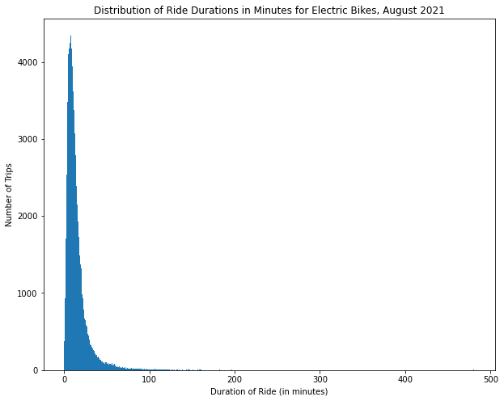

```python
binsize = 0.5
bins = np.arange(0, ebike_duration['ride_duration'].max()+binsize, binsize)

plt.figure(figsize=[10, 8])
plt.hist(data = ebike_duration, x = 'ride_duration', bins = bins)
plt.title('Distribution of Ride Durations in Minutes for Electric Bikes, August 2021')
plt.xlabel('Duration of Ride (in minutes)')
plt.ylabel('Number of Trips')
plt.show();
```

#### This chart has a long tail; let's transform this to a log scale.

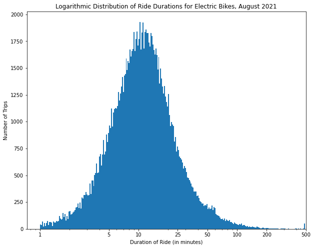

```python
log_binsize = 0.01
log_bins = 10 ** np.arange(0, np.log10(ebike_duration['ride_duration'].max()) + log_binsize, log_binsize)

plt.figure(figsize=[10, 8])
plt.hist(data = ebike_duration, x = 'ride_duration', bins = log_bins)
plt.title('Logarithmic Distribution of Ride Durations for Electric Bikes, August 2021')
plt.xlabel('Duration of Ride (in minutes)')
plt.ylabel('Number of Trips')
plt.xscale('log')
plt.xlim([0, 5e2])
plt.xticks([1, 5e0, 1e1, 2.5e1, 5e1, 1e2, 2e2, 5e2], ["1", "5", "10", "25", "50", "100", "200","500"])

plt.show()
```

#### Let's examine the ride duration on classic bikes.

```python
#ride duration on classic bike
classic_duration = df_clean[df_clean["bike_type"]=="classic_bike"]
```

```python
classic_duration["ride_duration"].describe()
```

```
count    64679.000000
mean        17.394187
std         42.077284
min          0.283333
25%          6.383333
50%         10.916667
75%         18.200000
max       1437.433333
Name: ride_duration, dtype: float64
```

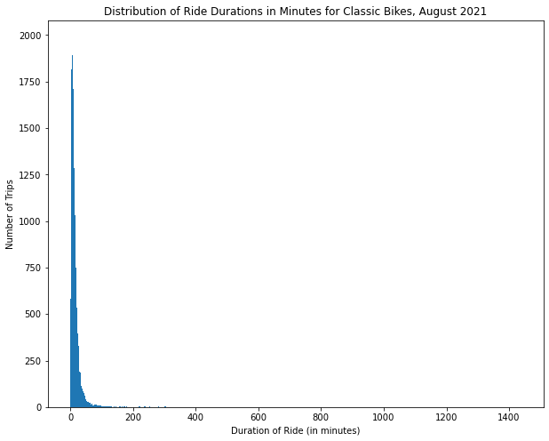

```python
binsize = 0.5
bins = np.arange(0, classic_duration['ride_duration'].max()+binsize, binsize)

plt.figure(figsize=[10, 8])
plt.hist(data = classic_duration, x = 'ride_duration', bins = bins)
plt.title('Distribution of Ride Durations in Minutes for Classic Bikes, August 2021')
plt.xlabel('Duration of Ride (in minutes)')
plt.ylabel('Number of Trips')
plt.show();
```

#### This chart has a long tail; let's transform this to a log scale.

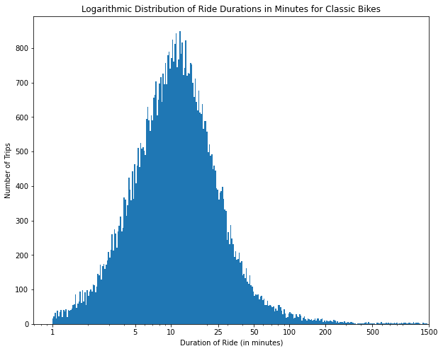

```python
log_binsize = 0.01
log_bins = 10 ** np.arange(0, np.log10(classic_duration['ride_duration'].max()) + log_binsize, log_binsize)

plt.figure(figsize=[10, 8])
plt.hist(data = classic_duration, x = 'ride_duration', bins = log_bins)
plt.title('Logarithmic Distribution of Ride Durations in Minutes for Classic Bikes')
plt.xlabel('Duration of Ride (in minutes)')
plt.ylabel('Number of Trips')
plt.xscale('log')
plt.xlim([0, 1.5e3])
plt.xticks([1, 5e0, 1e1, 2.5e1, 5e1, 1e2, 2e2, 5e2, 1.5e3], ["1", "5", "10", "25", "50", "100", "200", "500", "1500"])

plt.show()
```

#### Let's examine ride duration on docked bikes.

```python
#ride duration on docked bike
docked_duration = df_clean[df_clean["bike_type"]=="docked_bike"]
```

```python
docked_duration["ride_duration"].describe()
```

```
count    1930.000000
mean       48.278869
std       116.052503
min         1.083333
25%        14.395833
50%        23.758333
75%        40.662500
max      1384.650000
Name: ride_duration, dtype: float64
```

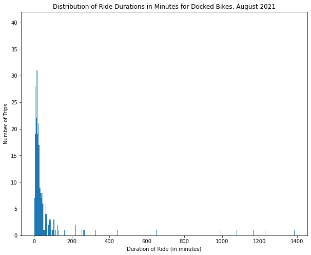

```python
binsize = 0.5
bins = np.arange(0, docked_duration['ride_duration'].max()+binsize, binsize)

plt.figure(figsize=[10, 8])
plt.hist(data = docked_duration, x = 'ride_duration', bins = bins)
plt.title('Distribution of Ride Durations in Minutes for Docked Bikes, August 2021')
plt.xlabel('Duration of Ride (in minutes)')
plt.ylabel('Number of Trips')
plt.show();
```

#### This chart sort of has a long tail; let's transform this to a log scale.

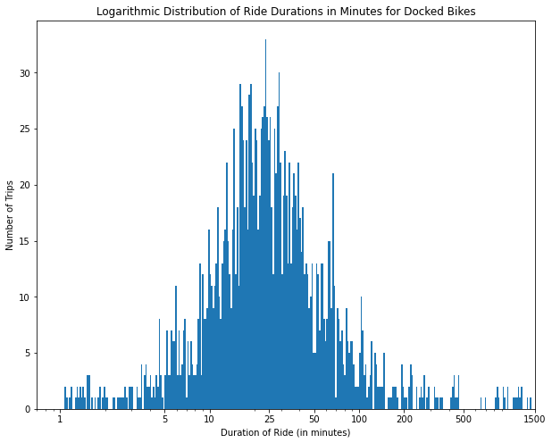

```python
log_binsize = 0.01
log_bins = 10 ** np.arange(0, np.log10(docked_duration['ride_duration'].max()) + log_binsize, log_binsize)

plt.figure(figsize=[10, 8])
plt.hist(data = docked_duration, x = 'ride_duration', bins = log_bins)
plt.title('Logarithmic Distribution of Ride Durations in Minutes for Docked Bikes')
plt.xlabel('Duration of Ride (in minutes)')
plt.ylabel('Number of Trips')
plt.xscale('log')
plt.xlim([0, 1.5e3])
plt.xticks([1, 5e0, 1e1, 2.5e1, 5e1, 1e2, 2e2, 5e2, 1.5e3], ["1", "5", "10", "25", "50", "100", "200", "500", "1500"])

plt.show()
```

#### On a log scale, the distribution of ride durations for docked bikes is roughly unimodal, with many spikes. If docked bikes are simply classic bikes ridden by casual riders on an all-day pass, perhaps it is not surprising that the median duration for rides on docked bikes is higher than the median duration for rides on classic or electric bikes. But we don't have enough information on docked bikes, and given the small number of docked bikes ridden, we won't investigate docked bikes any further.

#### The average (mean) ride for electric bikes is 15 minutes, which is less than the average ride for classic bikes (17 minutes) and docked bikes (48 minutes).

#### As stated previously, looking at all rides, mean is higher than the median, which indicates that the distribution is still right skewed. Also, the 75th percentile to maximum value spans ride durations from 17 minutes to just under 24 hours. A chart of these values will have a long tail on the right.

#### Since we'll be looking at hours and days of the week for rides, we will be creating columns for 1) the hour of day the ride started (based on a 24-hour clock) and 2) the day of the week the ride started.

```python
#create a column, start_datehour, which contains the hour (from 0 to 24) the ride started.
df_clean['start_datehour'] = df_clean['started_at'].dt.hour
```

```python
#create a column, end_datehour, which contains the hour (from 0 to 24) the ride ended.
df_clean['end_datehour'] = df_clean['ended_at'].dt.hour
```

```python
#create a column, "start_dayofweek, which contains the day of the week the ride started"
df_clean['start_dayofweek'] = df_clean['started_at'].dt.day_name()
```

```python
#create a column, "end_dayofweek, which contains the day of the week the ride ended"
df_clean['end_dayofweek'] = df_clean['ended_at'].dt.day_name()
```

```python
#make days of the week ordered categorical data types to make it easier to analyze data since
#days of the week have an order in real life
from pandas.api.types import CategoricalDtype

cats = ['Sunday','Monday', 'Tuesday', 'Wednesday', 'Thursday', 'Friday', 'Saturday']
cat_type = CategoricalDtype(categories=cats, ordered=True)

df_clean["start_dayofweek"] = df_clean["start_dayofweek"].astype(cat_type)
```

#### Given the large number of start station and end names where the value is "Unavailable," I won't be analyzing the start (or end station data) and will be calculating distance in kilometers between starting and ending latitude/longitude points to get a sense of possible ride distances, knowing that in some cases riders will return the bike to where they started.

#### I decided to apply the Haversine formula to calculate the distance in kilometers between two sets of latitude/longitude points. It obviously will not map the route that was actually traveled, but will give a rough idea of the kind of distances that riders will ride Bay Wheels. More on the Haversine formula can be found here:

https://en.wikipedia.org/wiki/Haversine_formula

```python
#a function that calculates the Haversine formula
def haversine(lat1, lon1, lat2, lon2, to_radians=True, earth_radius=6371):
    if to_radians:
        lat1, lon1, lat2, lon2 = np.radians([lat1, lon1, lat2, lon2])

    a = np.sin((lat2-lat1)/2.0)**2 + \
        np.cos(lat1) * np.cos(lat2) * np.sin((lon2-lon1)/2.0)**2

    return earth_radius * 2 * np.arcsin(np.sqrt(a))
```

#### Let's create a new column, dist_in_km, which is the distance in kilometers between two sets of latitude/longitude points:

```python
df_clean['dist_in_km'] = \
    haversine(df_clean["start_lat"], df_clean["start_lng"], df_clean["end_lat"], df_clean["end_lng"])
```

```python
df_clean.info() #checking
```

```
<class 'pandas.core.frame.DataFrame'>
Int64Index: 202655 entries, 0 to 207022
Data columns (total 19 columns):
 #   Column              Non-Null Count   Dtype
---  ------              --------------   -----
 0   ride_id             202655 non-null  object
 1   bike_type           202655 non-null  category
 2   ride_duration       202655 non-null  float64
 3   started_at          202655 non-null  datetime64[ns]
 4   ended_at            202655 non-null  datetime64[ns]
 5   start_station_name  202655 non-null  object
 6   start_station_id    202655 non-null  object
 7   end_station_name    202655 non-null  object
 8   end_station_id      202655 non-null  object
 9   start_lat           202655 non-null  float64
 10  start_lng           202655 non-null  float64
 11  end_lat             202655 non-null  float64
 12  end_lng             202655 non-null  float64
 13  rider_type          202655 non-null  category
 14  start_datehour      202655 non-null  int64
 15  end_datehour        202655 non-null  int64
 16  start_dayofweek     202655 non-null  category
 17  end_dayofweek       202655 non-null  object
 18  dist_in_km          202655 non-null  float64
dtypes: category(3), datetime64[ns](2), float64(6), int64(2), object(6)
memory usage: 26.9+ MB
```

```python
df_clean.describe()
```

|  | ride_duration | start_lat | start_lng | end_lat | end_lng | start_datehour | end_datehour | dist_in_km |
| --- | --- | --- | --- | --- | --- | --- | --- | --- |
| count | 202655.000000 | 202655.000000 | 202655.000000 | 202655.000000 | 202655.000000 | 202655.000000 | 202655.000000 | 202655.000000 |
| mean | 16.110585 | 37.749785 | -122.372217 | 37.749890 | -122.372001 | 14.202788 | 14.367516 | 2.018154 |
| std | 30.686298 | 0.116082 | 0.139002 | 0.116080 | 0.138958 | 4.867719 | 4.920221 | 1.453935 |
| min | 0.016667 | 37.280000 | -122.511282 | 37.240000 | -122.520000 | 0.000000 | 0.000000 | 0.000000 |
| 25% | 6.633333 | 37.764285 | -122.426964 | 37.764285 | -122.426628 | 11.000000 | 11.000000 | 0.999091 |
| 50% | 10.933333 | 37.776503 | -122.411336 | 37.776544 | -122.410887 | 15.000000 | 15.000000 | 1.717188 |
| 75% | 17.683333 | 37.789620 | -122.394672 | 37.790000 | -122.394586 | 18.000000 | 18.000000 | 2.739773 |
| max | 1437.433333 | 37.880222 | -121.810000 | 37.900000 | -121.790000 | 23.000000 | 23.000000 | 26.357329 |

#### The mean distance for a ride is almost 2 km, or 1.2 miles. The minimum value is 0 km, which is possible when start and end points are the same (in other words, when the rider ends the ride at the same location where the ride started). The maximum distance is 26 km (about 16 miles).

#### Given that we have a rough idea of the pricing scheme for Bay Wheels, we are going to estimate the cost for each ride. Because we can't tell if an electric bike is parked outside of the service area, we will not be applying the \$25 service fee, but if a bike's end_station_name is "Unavailable," we will be applying the \\$2 fee for not docking the bike at the end of the ride. Also, we don't know if a member if a monthly or annual member, so we will not be calculating any membership costs into a ride.

```python
#create a function, calculate, that calculates the cost for a ride, depending on the type of rider, the type of bike,
# the duration of the ride and whether the bike was docked at a station at the end of a ride if it was an electric bike.
import math
def calculate(ride_duration, bike_type, membership, end_station_name):
    cost = 0
    duration = round(ride_duration, 0)
    if membership=="member":  #if rider is a member
        if (bike_type=="classic_bike"): #if bike is classic
            if duration <= 45:
                cost = 0
            else:
                cost = math.ceil((duration-45)/15)*2
        elif bike_type=="electric_bike": #if bike is electric
            cost = duration*(0.15)
            if end_station_name == "Unavailable": #if electric bike not docked at end of ride
                cost = cost + 2
    elif membership == "casual": #if rider is casual
        if bike_type =="classic_bike":
            if duration <= 30:
                cost = 3.0
            else:
                cost = 3.0 + math.ceil((duration-30)/15)*3
        elif bike_type == "docked_bike": #if bike is docked, assume Access Pass was purchased for $10
            cost = 10.0
        elif bike_type == "electric_bike": #if bike is electric
            cost = 3+ duration*(0.20)
            if end_station_name == "Unavailable": #if electric bike not docked at end of ride
                cost = cost+2
    return round(cost, 2)
```

```python
#create a new column, est_ride_cost, that whose values will be the
df_clean['est_ride_cost'] = df_clean.apply(lambda x: calculate(x.ride_duration, x.bike_type, x.rider_type, x.end_station_name), axis=1)
```

```python
df_clean.info() #checking
```

```
<class 'pandas.core.frame.DataFrame'>
Int64Index: 202655 entries, 0 to 207022
Data columns (total 20 columns):
 #   Column              Non-Null Count   Dtype
---  ------              --------------   -----
 0   ride_id             202655 non-null  object
 1   bike_type           202655 non-null  category
 2   ride_duration       202655 non-null  float64
 3   started_at          202655 non-null  datetime64[ns]
 4   ended_at            202655 non-null  datetime64[ns]
 5   start_station_name  202655 non-null  object
 6   start_station_id    202655 non-null  object
 7   end_station_name    202655 non-null  object
 8   end_station_id      202655 non-null  object
 9   start_lat           202655 non-null  float64
 10  start_lng           202655 non-null  float64
 11  end_lat             202655 non-null  float64
 12  end_lng             202655 non-null  float64
 13  rider_type          202655 non-null  category
 14  start_datehour      202655 non-null  int64
 15  end_datehour        202655 non-null  int64
 16  start_dayofweek     202655 non-null  category
 17  end_dayofweek       202655 non-null  object
 18  dist_in_km          202655 non-null  float64
 19  est_ride_cost       202655 non-null  float64
dtypes: category(3), datetime64[ns](2), float64(7), int64(2), object(6)
memory usage: 28.4+ MB
```

#### Let's apply .describe() to the estimated ride cost column.

```python
#get an idea of the values for est_ride_cost
df_clean['est_ride_cost'].describe()
```

```
count    202655.000000
mean          4.396116
std           5.934375
min           0.000000
25%           1.500000
50%           3.200000
75%           6.000000
max         285.000000
Name: est_ride_cost, dtype: float64
```

#### It appears that 75 percent of rides cost \$6 or less. We'll take a look at the five most expensive rides.

```python
df_clean.sort_values(by = 'est_ride_cost', ascending=False).head()
```

|  | ride_id | bike_type | ride_duration | started_at | ended_at | start_station_name | start_station_id | end_station_name | end_station_id | start_lat | start_lng | end_lat | end_lng | rider_type | start_datehour | end_datehour | start_dayofweek | end_dayofweek | dist_in_km | est_ride_cost |
| --- | --- | --- | --- | --- | --- | --- | --- | --- | --- | --- | --- | --- | --- | --- | --- | --- | --- | --- | --- | --- |
| 177583 | C5896D194FE08F5D | classic_bike | 1436.200000 | 2021-08-07 16:08:04 | 2021-08-08 16:04:16 | Franklin St at 9th St | OK-M6 | Unavailable | Unavailable | 37.800516 | -122.272080 | 37.810000 | -122.270000 | casual | 16 | 16 | Saturday | Sunday | 1.070276 | 285.0 |
| 178786 | 225EE0CBA96A51D0 | classic_bike | 1437.433333 | 2021-08-16 18:31:38 | 2021-08-17 18:29:04 | Skyport Dr at Technology Dr | SJ-D9 | Unavailable | Unavailable | 37.365227 | -121.916815 | 37.370000 | -121.920000 | casual | 18 | 18 | Monday | Tuesday | 0.600806 | 285.0 |
| 129435 | F308EC1DE487F02F | classic_bike | 1382.933333 | 2021-08-15 13:46:03 | 2021-08-16 12:48:59 | Powell St BART Station (Market St at 4th St) | SF-G27 | Berry St at 4th St | SF-K29-1 | 37.786138 | -122.405234 | 37.775880 | -122.393170 | casual | 13 | 12 | Sunday | Monday | 1.557246 | 276.0 |
| 35456 | 63AB0276518E1BCD | classic_bike | 1369.583333 | 2021-08-12 11:48:13 | 2021-08-13 10:37:48 | Telegraph Ave at Carleton St | BK-F9 | Telegraph Ave at Carleton St | BK-F9 | 37.862320 | -122.258801 | 37.862320 | -122.258801 | casual | 11 | 10 | Thursday | Friday | 0.000000 | 273.0 |
| 161300 | AA8473A31AC15D3F | classic_bike | 1355.416667 | 2021-08-28 18:00:29 | 2021-08-29 16:35:54 | Pier 1/2 at The Embarcadero | SF-D29 | Lombard St at Columbus Ave | SF-B25 | 37.796389 | -122.394586 | 37.802767 | -122.413276 | casual | 18 | 16 | Saturday | Sunday | 1.788731 | 270.0 |

#### The five most expensive rides appear to be almost 24 hours in duration (rental period).

#### Let's apply .describe() to the estimated ride cost by rider type.

```python
df_clean['est_ride_cost'].groupby(df_clean["rider_type"]).describe()
```

| rider_type | count | mean | std | min | 25% | 50% | 75% | max |
| --- | --- | --- | --- | --- | --- | --- | --- | --- |
| casual | 119209.0 | 6.372933 | 6.739106 | 3.0 | 3.0 | 5.40 | 7.2 | 285.0 |
| member | 83446.0 | 1.572082 | 2.662625 | 0.0 | 0.0 | 1.05 | 2.4 | 152.0 |

#### The mean estimated ride cost is higher for casual members, which makes sense because members pay a reduced rate for electric bikes and the first 45 minutes of a classic bike ride is free.

#### Let's apply .describe() to the estimated ride cost by bike type.

```python
df_clean['est_ride_cost'].groupby(df_clean["bike_type"]).describe()
```

| bike_type | count | mean | std | min | 25% | 50% | 75% | max |
| --- | --- | --- | --- | --- | --- | --- | --- | --- |
| classic_bike | 64679.0 | 2.516257 | 8.020457 | 0.0 | 0.00 | 3.0 | 3.0 | 285.0 |
| docked_bike | 1930.0 | 10.000000 | 0.000000 | 10.0 | 10.00 | 10.0 | 10.0 | 10.0 |
| electric_bike | 136046.0 | 5.210340 | 4.369017 | 0.0 | 2.45 | 4.8 | 6.6 | 101.2 |

### What is the structure of your dataset?

In the uncleaned dataset, there were 207,023 Bay Wheels rides in the dataset with 13 columns (ride_id, rideable_type, started_at, ended_at, start_station_name, start_station_id, end_station_name, end_station_id, start_lat, start_lng, end_lat, end_lng, member_casual). Of the 13 columns, 4 are float data types and 9 are object data types.

### What is/are the main feature(s) of interest in your dataset?

I am interested in when the most trips are taken in terms of time of day and day of the week, the duration of the trips and how it might vary with the type of membership or the type of bike. I am also curious as to whether the distance between starting and ending latitude/longitudes has any correlation to these variables. Finally, I am curious about the estimated cost per ride.

### What features in the dataset do you think will help support your investigation into your feature(s) of interest?

The start and end times of the rides (start_datehour, end_datehour, start_dayofweek, end_dayofweek), the bike type (bike_type), the membership type (rider_type), the distance (dist_in_km) and the estimated cost of a ride (est_ride_cost).

## Univariate Exploration

> Let's explore the following variables individually: ride_duration, bike_type, rider_type, start_datehour, end_datehour, start_dayofweek, end_dayofweek, start_station_name, end_station_name, dist_in_km, est_ride_cost.

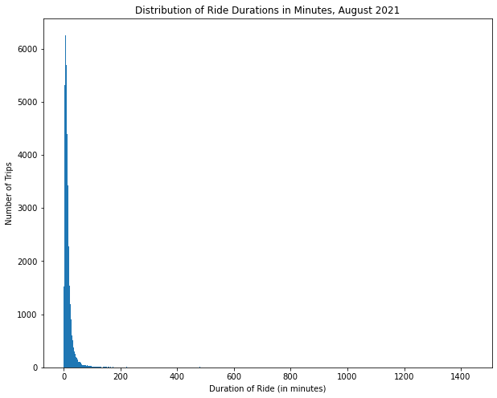

```python
#exploring ride_duration
binsize = 0.5
bins = np.arange(0, df_clean['ride_duration'].max()+binsize, binsize)

plt.figure(figsize=[10, 8])
plt.hist(data = df_clean, x = 'ride_duration', bins = bins)
plt.title('Distribution of Ride Durations in Minutes, August 2021')
plt.xlabel('Duration of Ride (in minutes)')
plt.ylabel('Number of Trips')
plt.show()
```

#### It looks like the majority of rides are short -- but there is a long tail, which suggests that this data might be suited for a logarithmic scale.

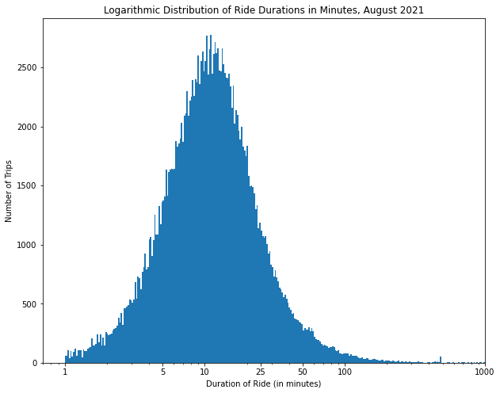

```python
log_binsize = 0.01
log_bins = 10 ** np.arange(0, np.log10(df_clean['ride_duration'].max()) + log_binsize, log_binsize)

plt.figure(figsize=[10, 8])
plt.hist(data = df_clean, x = 'ride_duration', bins = log_bins)
plt.title('Logarithmic Distribution of Ride Durations in Minutes, August 2021')
plt.xlabel('Duration of Ride (in minutes)')
plt.ylabel('Number of Trips')
plt.xscale('log')
plt.xlim([0, 1e3])
plt.xticks([1, 5e0, 1e1, 2.5e1, 5e1, 1e2, 1e3], ["1", "5", "10", "25", "50", "100", "1000"])

plt.show()
```

#### When plotted on a log-scale, the ride duration distribution is roughly unimodal, with a peak clustered at about 10 minutes. The number of rides longer than 10 minutes begins to drop quickly after that.

#### Let's examine the distribution of ride duration for electric bikes.

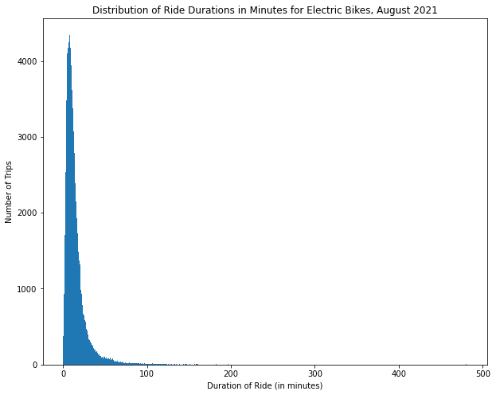

```python
binsize = 0.5
bins = np.arange(0, ebike_duration['ride_duration'].max()+binsize, binsize)

plt.figure(figsize=[10, 8])
plt.hist(data = ebike_duration, x = 'ride_duration', bins = bins)
plt.title('Distribution of Ride Durations in Minutes for Electric Bikes, August 2021')
plt.xlabel('Duration of Ride (in minutes)')
plt.ylabel('Number of Trips')
plt.show();
```

#### This chart has a long tail; let's transform this to a log scale.

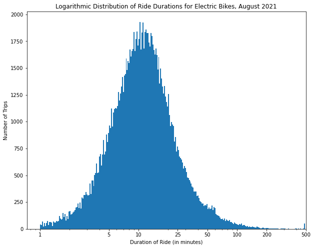

```python
log_binsize = 0.01
log_bins = 10 ** np.arange(0, np.log10(ebike_duration['ride_duration'].max()) + log_binsize, log_binsize)

plt.figure(figsize=[10, 8])
plt.hist(data = ebike_duration, x = 'ride_duration', bins = log_bins)
plt.title('Logarithmic Distribution of Ride Durations for Electric Bikes, August 2021')
plt.xlabel('Duration of Ride (in minutes)')
plt.ylabel('Number of Trips')
plt.xscale('log')
plt.xlim([0, 5e2])
plt.xticks([1, 5e0, 1e1, 2.5e1, 5e1, 1e2, 2e2, 5e2], ["1", "5", "10", "25", "50", "100", "200","500"])

plt.show()
```

#### Let's examine the ride duration on classic bikes.

```python
#ride duration on classic bike
classic_duration = df_clean[df_clean["bike_type"]=="classic_bike"]
```

```python
classic_duration["ride_duration"].describe()
```

```
count    64679.000000
mean        17.394187
std         42.077284
min          0.283333
25%          6.383333
50%         10.916667
75%         18.200000
max       1437.433333
Name: ride_duration, dtype: float64
```

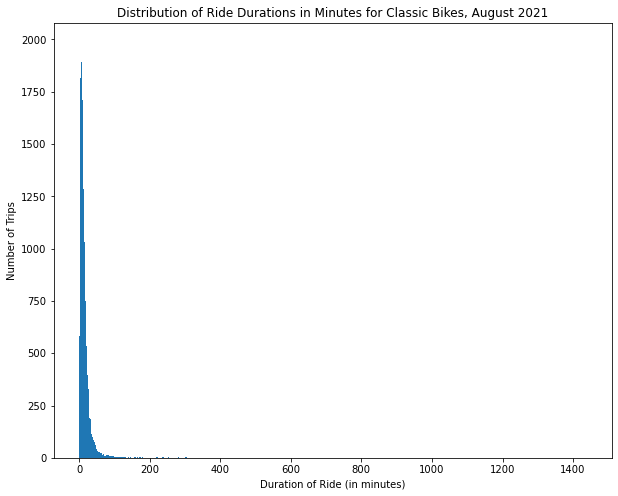

```python
binsize = 0.5
bins = np.arange(0, classic_duration['ride_duration'].max()+binsize, binsize)

plt.figure(figsize=[10, 8])
plt.hist(data = classic_duration, x = 'ride_duration', bins = bins)
plt.title('Distribution of Ride Durations in Minutes for Classic Bikes, August 2021')
plt.xlabel('Duration of Ride (in minutes)')
plt.ylabel('Number of Trips')
plt.show();
```

#### This chart has a long tail; let's transform this to a log scale.

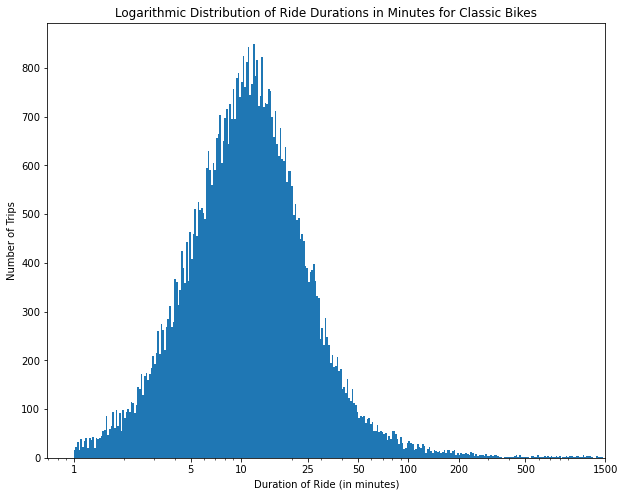

```python
log_binsize = 0.01
log_bins = 10 ** np.arange(0, np.log10(classic_duration['ride_duration'].max()) + log_binsize, log_binsize)

plt.figure(figsize=[10, 8])
plt.hist(data = classic_duration, x = 'ride_duration', bins = log_bins)
plt.title('Logarithmic Distribution of Ride Durations in Minutes for Classic Bikes')
plt.xlabel('Duration of Ride (in minutes)')
plt.ylabel('Number of Trips')
plt.xscale('log')
plt.xlim([0, 1.5e3])
plt.xticks([1, 5e0, 1e1, 2.5e1, 5e1, 1e2, 2e2, 5e2, 1.5e3], ["1", "5", "10", "25", "50", "100", "200", "500", "1500"])

plt.show()
```

#### Let's examine ride duration on docked bikes.

```python
#ride duration on docked bike
docked_duration = df_clean[df_clean["bike_type"]=="docked_bike"]
```

```python
docked_duration["ride_duration"].describe()
```

```
count    1930.000000
mean       48.278869
std       116.052503
min         1.083333
25%        14.395833
50%        23.758333
75%        40.662500
max      1384.650000
Name: ride_duration, dtype: float64
```

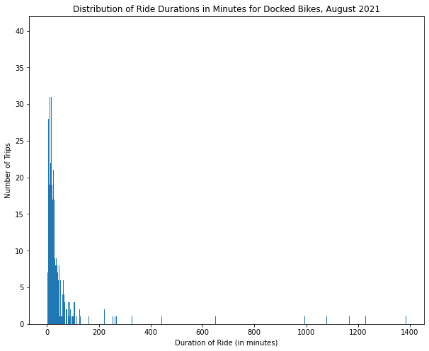

```python
binsize = 0.5
bins = np.arange(0, docked_duration['ride_duration'].max()+binsize, binsize)

plt.figure(figsize=[10, 8])
plt.hist(data = docked_duration, x = 'ride_duration', bins = bins)
plt.title('Distribution of Ride Durations in Minutes for Docked Bikes, August 2021')
plt.xlabel('Duration of Ride (in minutes)')
plt.ylabel('Number of Trips')
plt.show();
```

#### This chart has a long tail; let's transform this to a log scale.

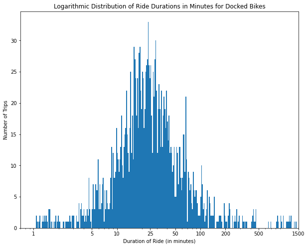

```python
log_binsize = 0.01
log_bins = 10 ** np.arange(0, np.log10(docked_duration['ride_duration'].max()) + log_binsize, log_binsize)

plt.figure(figsize=[10, 8])
plt.hist(data = docked_duration, x = 'ride_duration', bins = log_bins)
plt.title('Logarithmic Distribution of Ride Durations in Minutes for Docked Bikes')
plt.xlabel('Duration of Ride (in minutes)')
plt.ylabel('Number of Trips')
plt.xscale('log')
plt.xlim([0, 1.5e3])
plt.xticks([1, 5e0, 1e1, 2.5e1, 5e1, 1e2, 2e2, 5e2, 1.5e3], ["1", "5", "10", "25", "50", "100", "200", "500", "1500"])

plt.show()
```

#### Let's examine the type of bikes ridden in August 2021.

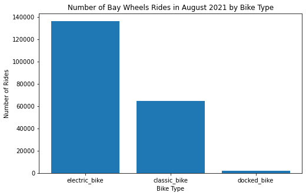

```python
# plotting types of bikes on bar chart.
fig = plt.figure(figsize=[8,5])
plt.bar(x = df_clean["bike_type"].value_counts().keys(), height = df_clean["bike_type"].value_counts())
plt.title('Number of Bay Wheels Rides in August 2021 by Bike Type')
plt.xlabel('Bike Type')
plt.ylabel('Number of Rides')
plt.show()
```

#### The majority of bikes ridden in August 2021 are electric bikes. The number of classic bikes are half the number of electric bikes, and a very small number of bikes ridden are docked bikes. Based on my exploration of the dataset, I think that docked bikes are simply classic bikes rented by casual riders with an Access Pass. It is unclear why they are a separate category.